# Exploring nonlinearTseries for understanding and the A-life paper

Robert Kramer, developed from nonlinearTseries quickstart

4/17/2017

Dale– I was going through this while working on my A-life project and thought I would use it. I have commented the requirements (# req) of the lab for easier evaluation. Just find ‘# req’ –Robert

```r
# req 2d and random number (wasn't sure if df with 3 counted)
a <- matrix(sample.int(10,200, replace = T),ncol = 2)

# req function if else then
requirement <- function(a){
  if(a<5){print("low")}
    else{print("high")}
  ifelse(a<2,print("really low"),print("not really low"))
}


# req while loop
i=1
while(i<10){
  print(a[i])
  requirement(a[i])
  i <- i +1
}
```

```
## [1] 7
## [1] "high"
## [1] "not really low"
## [1] 10
## [1] "high"
## [1] "not really low"
## [1] 10
## [1] "high"
## [1] "not really low"
## [1] 9
## [1] "high"
## [1] "not really low"
## [1] 6
## [1] "high"
## [1] "not really low"
## [1] 6
## [1] "high"
## [1] "not really low"
## [1] 2
## [1] "low"
## [1] "not really low"
## [1] 7
## [1] "high"
## [1] "not really low"
## [1] 1
## [1] "low"
## [1] "really low"
```

```r
# req if,then, else ## I had a bunch, but forgot I found other solutions
```

```r
# req heading level 1
```

# MSE

There are 2 steps

1. Course graining the signal data

```r
# req math formula
```

$$y_j^{(\tau)}=\frac{1}{\tau}\sum_{i=(j-1)\tau+1}^{j\tau} x_i, \qquad 1 \leq j \leq N/\tau$$

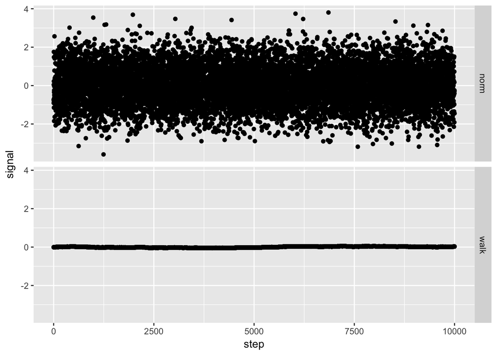

```r
# fake signal data
sample.period <- 10000 # have to use 10,000 for corrdim to work, but looks better at like 100
# req 1d
sig1 <- rnorm(sample.period)

# random walk
n = sample.period

# req funcion
walk <- function(n){
  x = 0
  for(i in 2:n){
    x[i] <- x[i-1]+sample(1,x = c(-1, 1))
  }
  x <- (x-mean(x))/var(x) # standardization
  return(x)
}
sig2 <- walk(sample.period)

sigs <- data.frame(
  signal=c(sig1,sig2),
  type=c(rep("norm",n),rep("walk",n)),
  step=c(1:n,1:n)
  )

plt <- ggplot(sigs, aes(x=step,y=signal)) +
  geom_point() +
  facet_grid(type ~ .)
plt
```

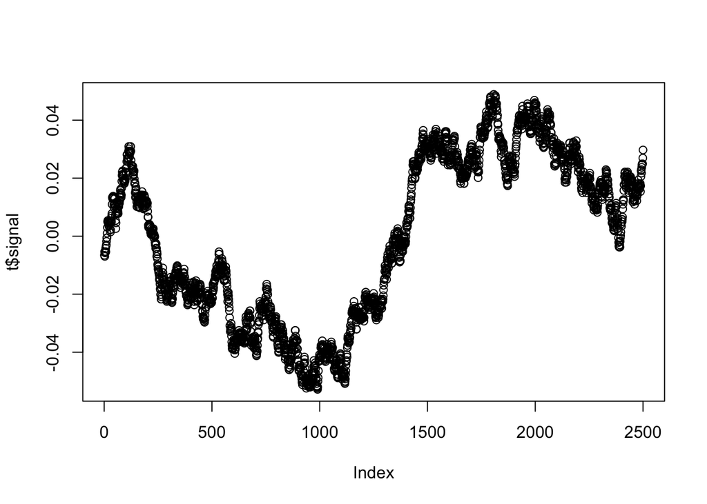

```r
# course graining procedure


course <- function(sig, tau){
  y=0
  i=1
  for(j in seq(1,round(n/tau))){
    i <- (j-1)*tau+1
    y[j] <- mean(sig[seq(i,j*tau)])
  }
  return(y)
}

tau = 4
t <- course(sig2, tau)
t <- data.frame(
  signal=t,
  type="coarse4",
  step=seq(1,n,by=tau))
plot(t$signal)
```

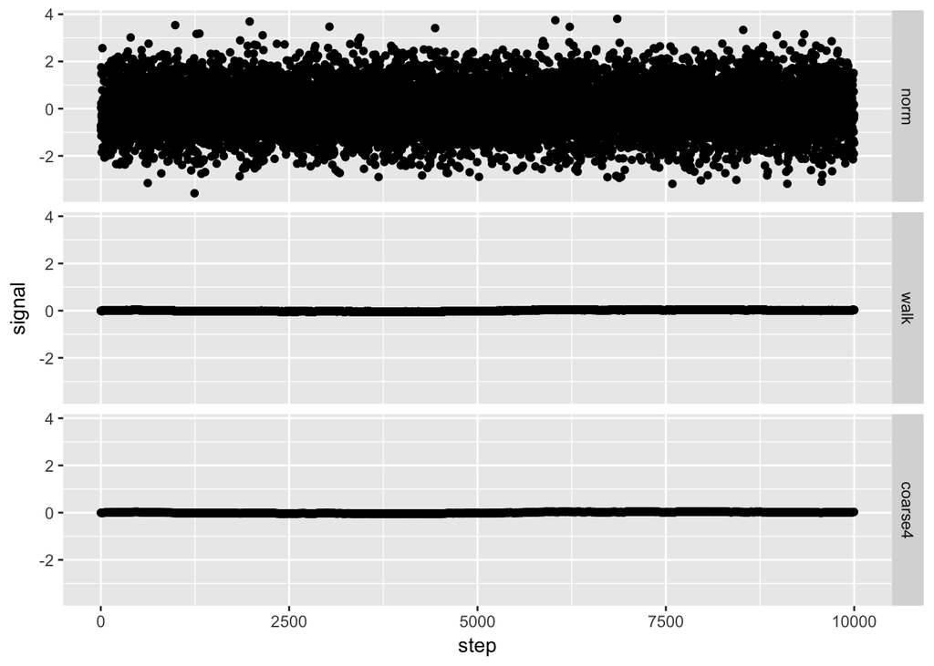

```r
sigs <- rbind(sigs,t)
# req plot
plt <- ggplot(sigs, aes(x=step,y=signal)) +
  geom_point() +
  facet_grid(type ~ .)
plt
```

```r
# req heading level 2
```

## 2. Sample Entropy

$$SampEn(m,r,N)=-ln \frac{A^m(r)}{B^m(r)}$$

```r
# req bold and italics
```

$A^m(r)=$probability a sequence of length m+1 matches the other sequences of length m+1 withing a **tolerance** of r in a *signal* of N length not including itself

```r
m <- tau
r <- .15 # heuristic of .15*sd is typically used, we use standardized values with an sd=1
N <- n
############ following nonlinearTquickstart from here just for sig1 --> random normal
# Using nonlinear T series
# sig1corr <- corrDim(sig1,2,5,1,.1,r)
```

We need to estimate the embedding dimension $m$ and the time lag $\tau$

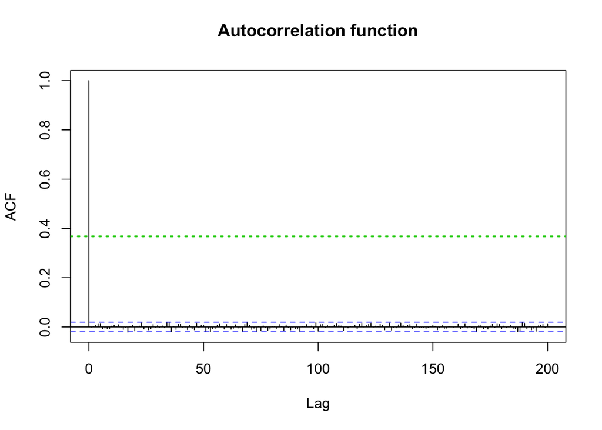

```r
# tau-delay estimation based on the mutual information function
lag.max <- 200

tau.acf1 = timeLag(sig1, technique = "acf",
                  lag.max = lag.max, do.plot = T)
```

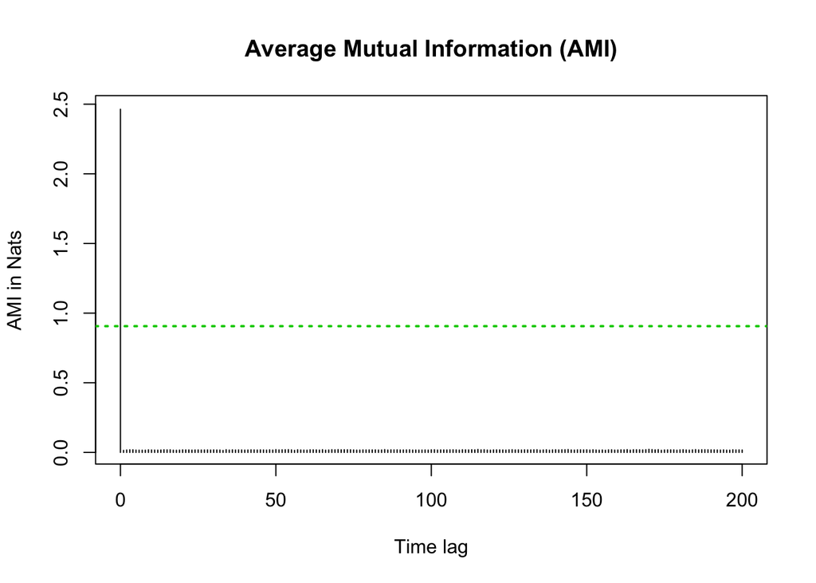

```r
tau.ami1 = timeLag(sig1, technique = "ami",
                  lag.max =lag.max, do.plot = T)
```

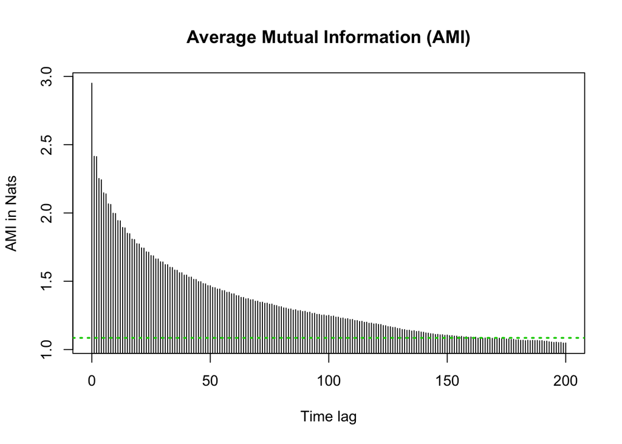

```r
# tau.acf2 = timeLag(sig2, technique = "acf",
#                   lag.max = lag.max, do.plot = T, selection.method = "first.value" ) # doesn't work for this

tau.ami2 = timeLag(sig2, technique = "ami",
                  lag.max = lag.max, do.plot = T)
```

## using Cao’s algorithm to find embedding dim

“Practical method for determining the minimum embedding dimension of a scalar time series”
$$y(d)=(x_i, x_{i+\tau}, ...,x_{i+(d-1)\tau})$$

```r
x <- sig2 # time series x
d <- 3 # embedding dimension
t <- 1 # time delay

# for (1,2,3,4,5,6) d=2, tau = 2
# y = [[1,3],[2,4],[3,5],[5,6]]
# y in [1,...,p]
t.delay.vec <- function(x,d,tau){
  y = list()
  p <- length(x)-(d-1)*tau
  for(i in 1:p){
    x.seq <- seq(i,i+(d-1)*tau,by=tau)
    y[[i]] <- x[x.seq]
  }
  return(y)
}

y <- t.delay.vec(x,d,t)
```

```r
emb.dim1 = estimateEmbeddingDim(sig1, time.lag = tau.ami1,
                               max.embedding.dim = 20)
```

[figure not shown]

```r
emb.dim2 = estimateEmbeddingDim(sig2, time.lag = tau.ami2,
                               max.embedding.dim = 20)
```

[figure not shown]

$E1(d)$ stops changing when $d \geq embedding dimension$ $E2(d)$ is $~1$ for stocastic systems and $~0$ (just not equal to 1 in paper??) for deterministic systems. This is a result of the embedding dimension capturing the underlying couplings of the nonlinear function if they exist. $E2(d)$ is a function of the differences between the ratio of $d+1$ vectors to $d$ vectors.

On to building the takens to attempt to reconstruct the phase space

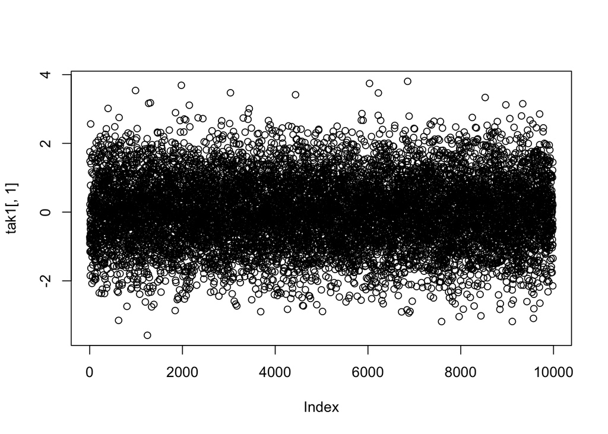

```r
tak1 = buildTakens(sig1,embedding.dim = emb.dim1, time.lag = tau.ami1)
plot(tak1[,1])
```

```r
# scatter3D(tak[,1], tak[,2], tak[,3],
#           main = "Lorenz's system reconstructed phase space",
#           col = 1, type="o",cex = 0.3)

# tak2 = buildTakens(sig2,embedding.dim = emb.dim2, time.lag = tau.ami2)
# plot(tak2[,1])
```

# computing nonlinear statistics

## Lyapunov, Generalized Correlation dimension, Sample entropy

```r
# req heading bullet and numbered list some are 2 deep
```

- heavy computations
  1. scaling behavior over time –> correlation dimension
  2. dynamical evolution over time –> Lyapunov exponent
- Find linear region for statistic
- the statistics should be invarient given a high enough embedding dimension
  - Look for linear behavior of a region in plots to recognize this
- estimation of invariant is found through a linear regression of previous region

# Correlation Dimension

The correlation dimension measures the fractal dimension in phase space of a dynamical system. * Need to find an invarient region. * typically start with embedding region calculated before and check for like 5 more. * We vary our radius or the $\epsilon$ around the “matching” criteria to potentially compensate for noise. Shouldn’t really matter as these systems are essentially noise

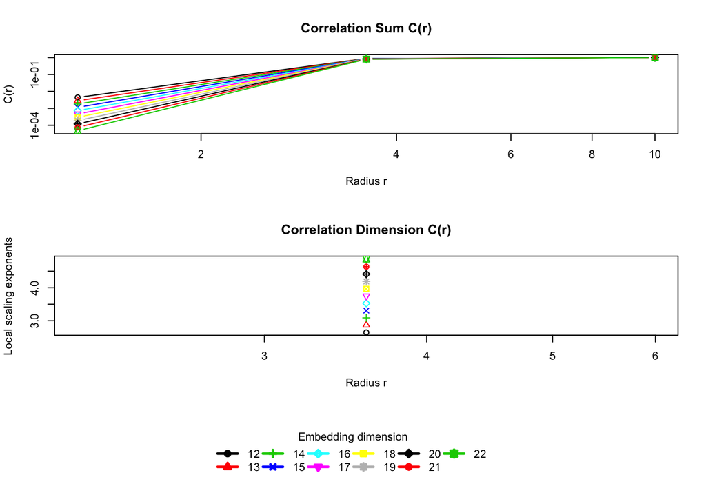

```r
cd1 = corrDim(sig1,
             min.embedding.dim = emb.dim1,
             max.embedding.dim = emb.dim1 + 10,
             time.lag = tau.ami1,
             min.radius = 0.001, max.radius = 10,
             n.points.radius = 10,
             theiler.window = 1000,
             do.plot=T)
plot(cd1)
```

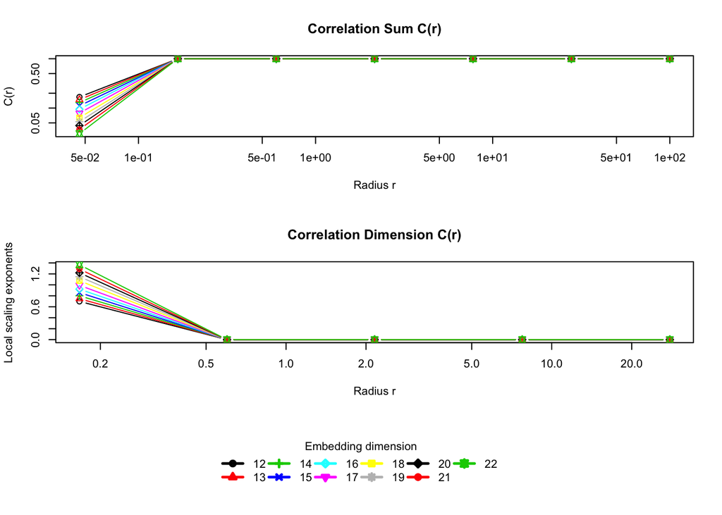

```r
cd2 = corrDim(sig2,
             min.embedding.dim = emb.dim2,
             max.embedding.dim = emb.dim2 + 10,
             time.lag = tau.ami2,
             min.radius = 0.001, max.radius = 100,
             n.points.radius = 10,
             theiler.window = 1000,
             do.plot=FALSE)
plot(cd2)
```

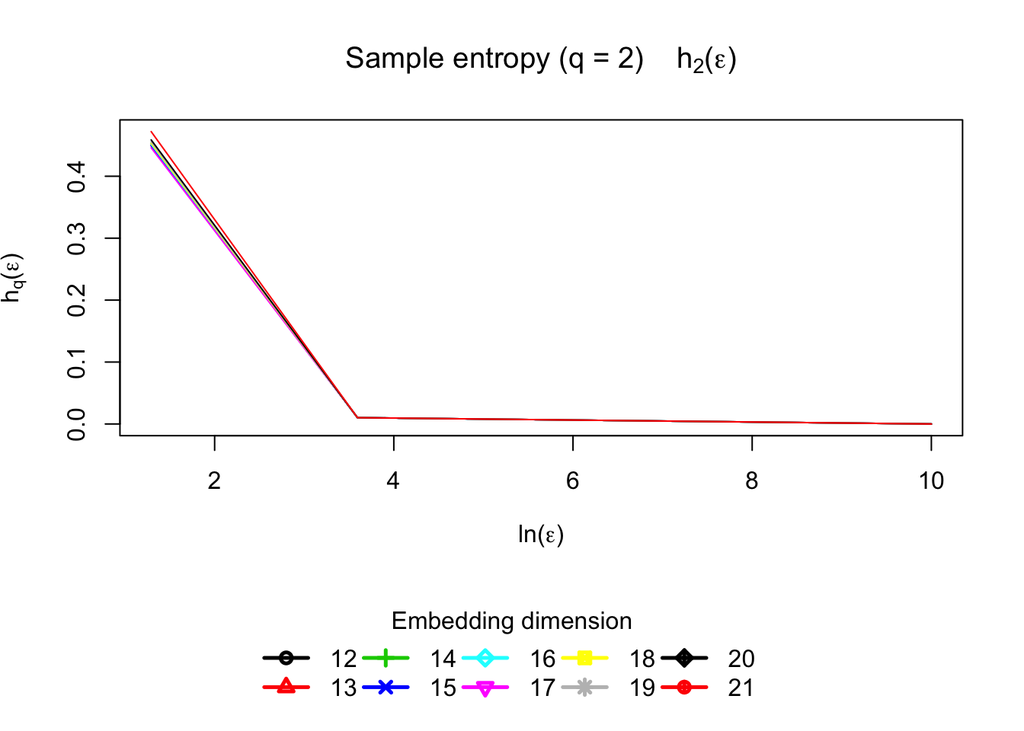

```r
# sample entropy
se1 = sampleEntropy(cd1, do.plot = T)
```

```r
se.est1 = estimate(se1, do.plot = F,
                  regression.range = c(0,4))
cat("Sample entropy estimate for noise: ", mean(se.est1), "\n")
```

```
## Sample entropy estimate for noise:  0.2322055
```

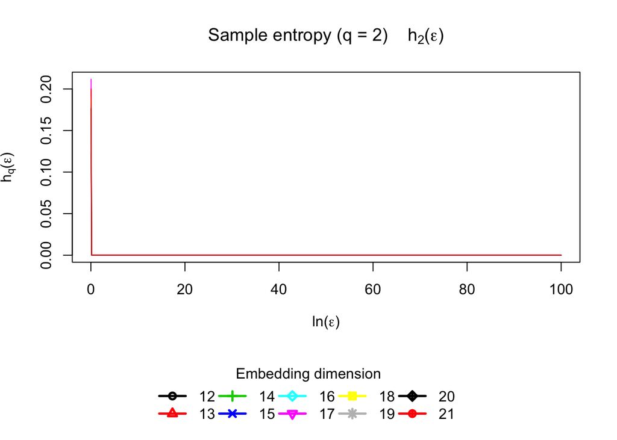

```r
se2 = sampleEntropy(cd2, do.plot = T)
```

```r
se.est2 = estimate(se1, do.plot = F,
                  regression.range = c(1,10))
# cat("Sample entropy estimate for walk: ", mean(se.est2), "\n")
```

## Max Lyapunov

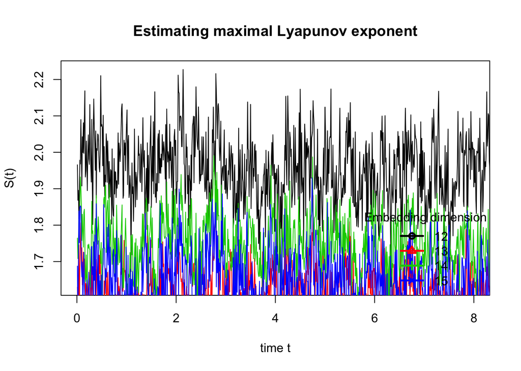

```r
# get the sampling period of the lorenz simulation
# computing the differences of time (all differences should be equal)
sampling.period = sample.period# diff(lor$time)[1]
ml1 = maxLyapunov(sig1,
                 sampling.period=0.01,
                 min.embedding.dim = emb.dim1,
                 max.embedding.dim = emb.dim1 + 3,
                 time.lag = tau.ami1,
                 radius=1,
                 max.time.steps=1000,
                 do.plot=FALSE)
plot(ml1,type="l", xlim = c(0,8))
```

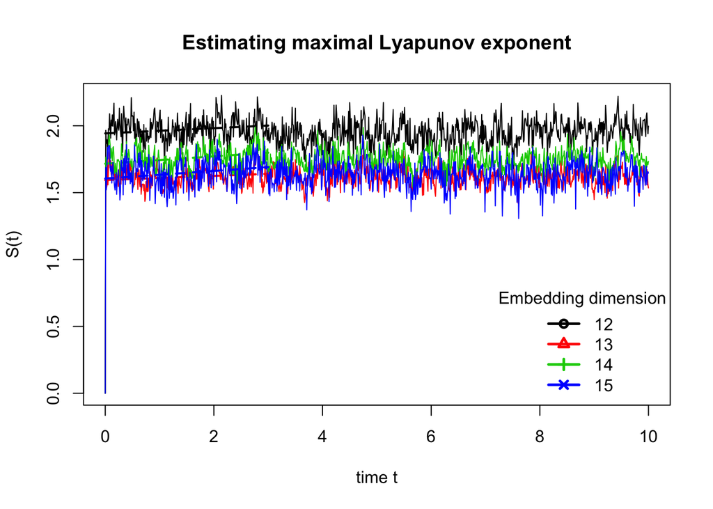

```r
ml.est = estimate(ml1, regression.range = c(0,3),
                  do.plot = T,type="l")
```

```r
# cat("expected: 0.906  --- estimate: ", ml1.est,"\n")
```

Noise is not the lorenz system, so that’s pretty good. The next step is to use my simulation data with this process and compare it to a random walk